# DataVis_task

Evgenii Berdinskikh

2024-09-27

## Загрузка данных

```r
data <- read_csv("data/raw/hogwarts_2024.csv") %>%
  mutate(across(where(is.character), function(x) as.factor(x)))
```

## Столбчатые диаграммы

### Задание 1:

- Постройте барплот (столбчатую диаграмму), отражающую распределение числа студентов по курсу обучения.
- Примените любую из встроенных тем ggplot.
- Раскрасьте столбики любым понравившимся вам цветом (можно использовать как словесные обозначения, так и гекскоды).
- Добавьте цвет контура столбиков.

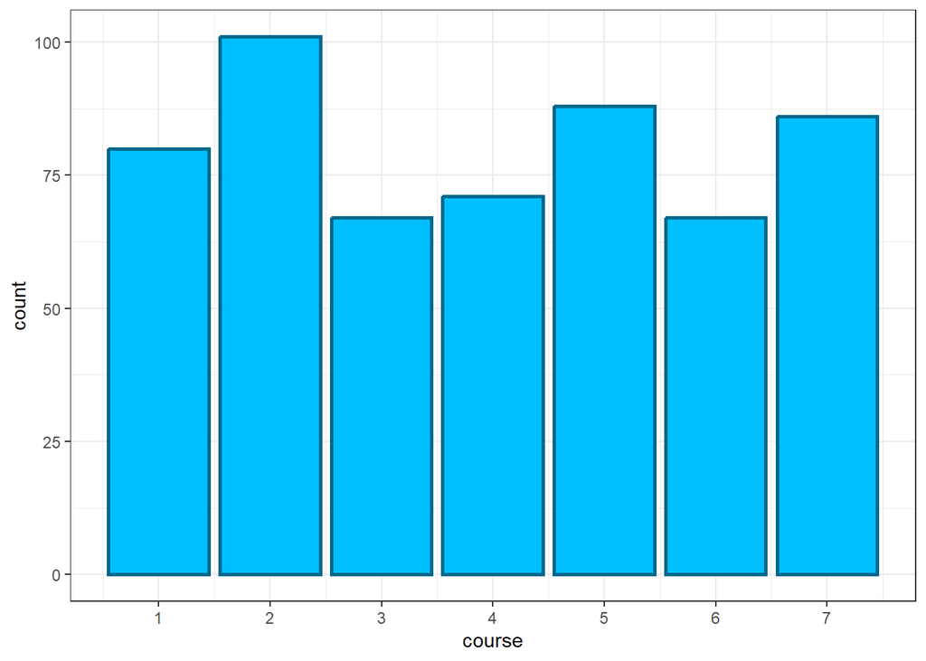

```r
ggplot(data) +
  geom_bar(aes(x = course), fill = "deepskyblue", colour = "deepskyblue4", linewidth  = 1) +
  scale_x_continuous(breaks = seq(1,max(data$course),1))+
  theme_bw()
```

### Задание 2:

- Создайте новый барплот, отражающий распределение числа студентов по факультету.
- Добавьте на график вторую факторную переменную – происхождение (bloodStatus).
- Модифицируйте при помощи аргумента position график так, чтобы каждый столбец показывал распределение факультета по чистоте крови в долях.
- Примените произвольную тему.
- Запишите текстом в rmd-документе, какой вывод можно сделать из графика?

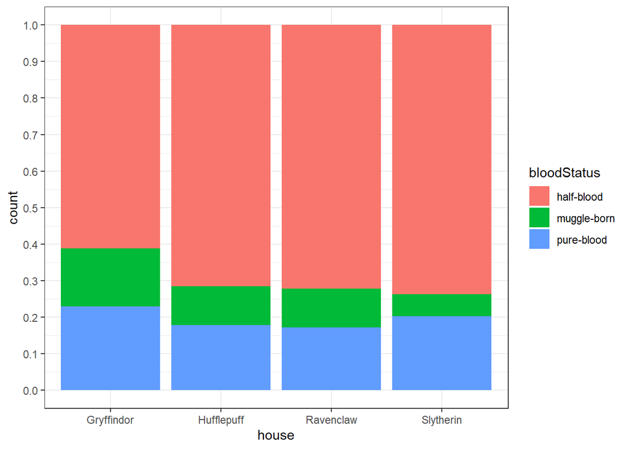

```r
ggplot(data)+
  geom_bar(aes(x = house, fill = bloodStatus), position = "fill")+
  scale_y_continuous(breaks = seq(0,1,0.1))+
  theme_bw()
```

**Вывод:** Наибольшая доля чистокровных студентов — в Гриффиндоре и Слизерине. В Слизерине самая низкая доля маглов, а в Гриффиндоре — самая высокая.

### Задание 3:

- Модифицируйте датасет таким образом, чтобы в нем остались только чистокровные (pure-blood) и маглорожденные студенты (muggle-born).
- Создайте на основе этих данных график из пункта 2.
- Добавьте горизонтальную пунктирную линию произвольного цвета на уровне 50%.
- Дайте осям название на русском языке.
- Переименуйте на русский язык категории легенды pure-blood и muggle-born.

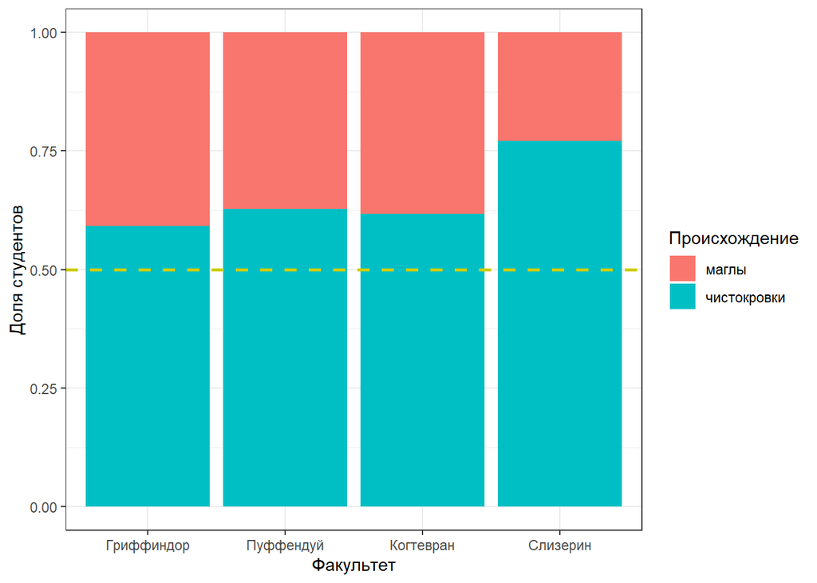

```r
data %>%
  filter(bloodStatus != "half-blood") %>%
  ggplot(aes(x = fct_recode(house, Гриффиндор = "Gryffindor", Пуффендуй = "Hufflepuff",
                            Когтевран = "Ravenclaw", Слизерин = "Slytherin"),
             fill = fct_recode(bloodStatus, маглы = "muggle-born", чистокровки = "pure-blood")))+
  geom_bar(position = "fill")+
  geom_hline(yintercept = 0.5, linetype = "dashed", colour = "yellow3", linewidth = 1)+
  theme_bw()+
  labs(x = "Факультет", y = "Доля студентов", fill = "Происхождение")
```

## Боксплоты

### Задание 1:

- Отобразите распределение баллов, заработанных студентами на 3-й неделе обучения, по факультетам.
- Отсортируйте факультеты в порядке убывания медианного балла за 3-ю неделю.

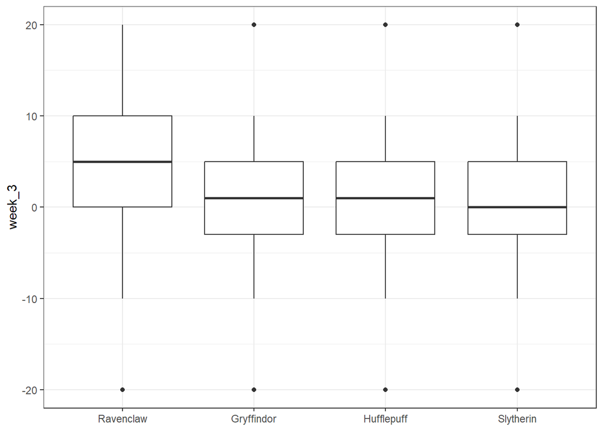

```r
ggplot(data) +
  geom_boxplot(aes(x = fct_reorder(house, week_3, .desc = TRUE), y = week_3)) +
  labs(x = NULL)+
  theme_bw()
```

### Задание 2:

- Добавьте отображение разными цветами для происхождения студентов (bloodStatus).
- Добавьте на боксплот вырезку (notch).
- Настройте для данного чанка размер изображения 14:14 дюймов.
- Приведите названия осей к корректному виду.

[output not shown]

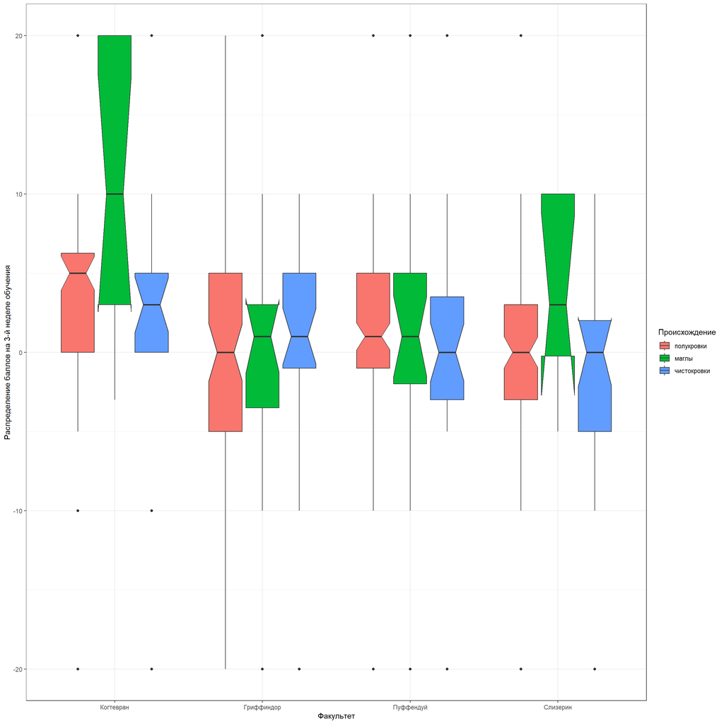

```r
ggplot(data) +
  geom_boxplot(aes(x = fct_reorder(fct_recode(house, Гриффиндор = "Gryffindor", Пуффендуй = "Hufflepuff",
                            Когтевран = "Ravenclaw", Слизерин = "Slytherin"), week_3, .desc = TRUE),
                   y = week_3, fill = fct_recode(bloodStatus, маглы = "muggle-born",
                                                 чистокровки = "pure-blood", полукровки = "half-blood")),
               notch = TRUE) +
  labs(x = "Факультет", y = "Распределение баллов на 3-й неделе обучения", fill = "Происхождение")+
  theme_bw()
```

### Задание 3:

- Добавьте на график джиттер-плот.
- Удалите отображение выбросов у боксплота.
- Видоизмените по своему вкусу толщину линий и ширину боксплота.
- Добавьте название графика и подпись

[output not shown]

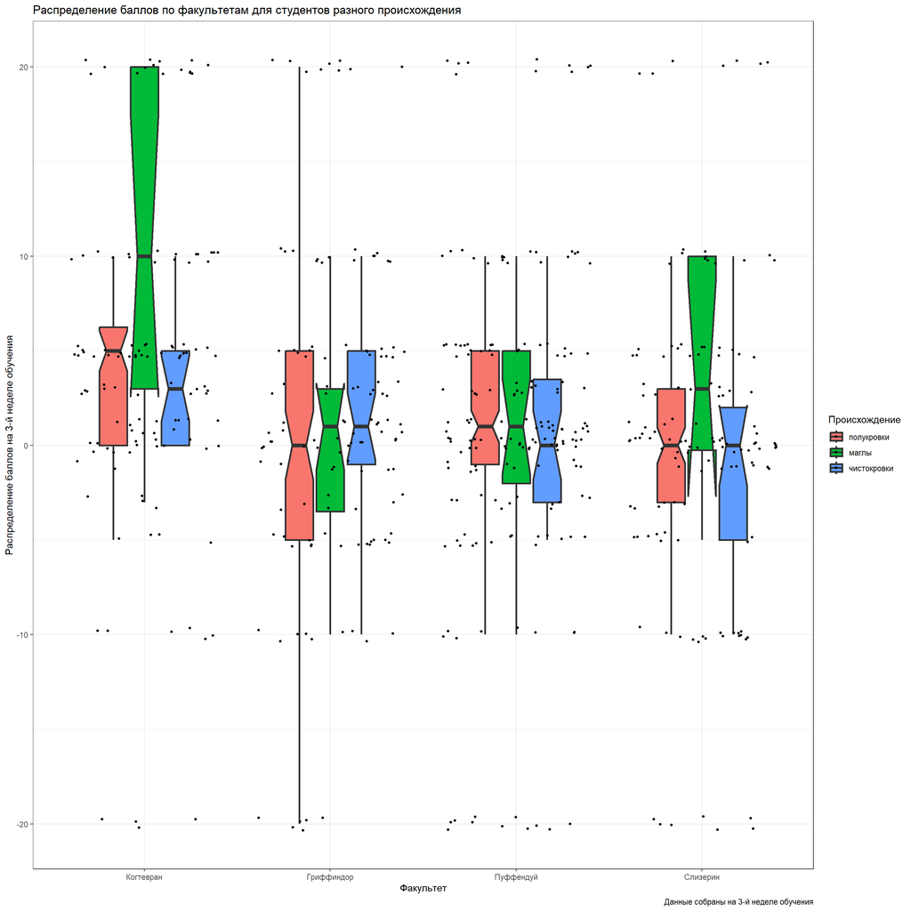

```r
ggplot(data, aes(x = fct_reorder(fct_recode(house, Гриффиндор = "Gryffindor", Пуффендуй = "Hufflepuff",
                                            Когтевран = "Ravenclaw", Слизерин = "Slytherin"), week_3, .desc = TRUE),
                 y = week_3, fill = fct_recode(bloodStatus, маглы = "muggle-born", чистокровки = "pure-blood",
                                               полукровки = "half-blood"))) +
  geom_boxplot(notch = TRUE, outliers = FALSE, linewidth = 1, width = 0.5) +
  geom_jitter(size = 1) +
  labs(x = "Факультет", y = "Распределение баллов на 3-й неделе обучения", fill = "Происхождение",
       title = "Распределение баллов по факультетам для студентов разного происхождения",
       caption = "Данные собраны на 3-й неделе обучения")+
  theme_bw()
```

## Разное

### Задание 1:

- Постройте “леденцовый график” (lollipop-plot) для количества набранных студентами 5-го курса баллов за весь учебный год (по оси ординат – id студента, по оси абсцисс – итоговый балл).
- Отсортируйте студентов в порядке убывания итогового балла.
- Раскрасьте точки на “леденцах” в зависимости от сердцевины волшебной палочки. Палочки с сердечной жилой дракона должны быть красного цвета, с пером феникса – желтого, с волосом единорога – серого.

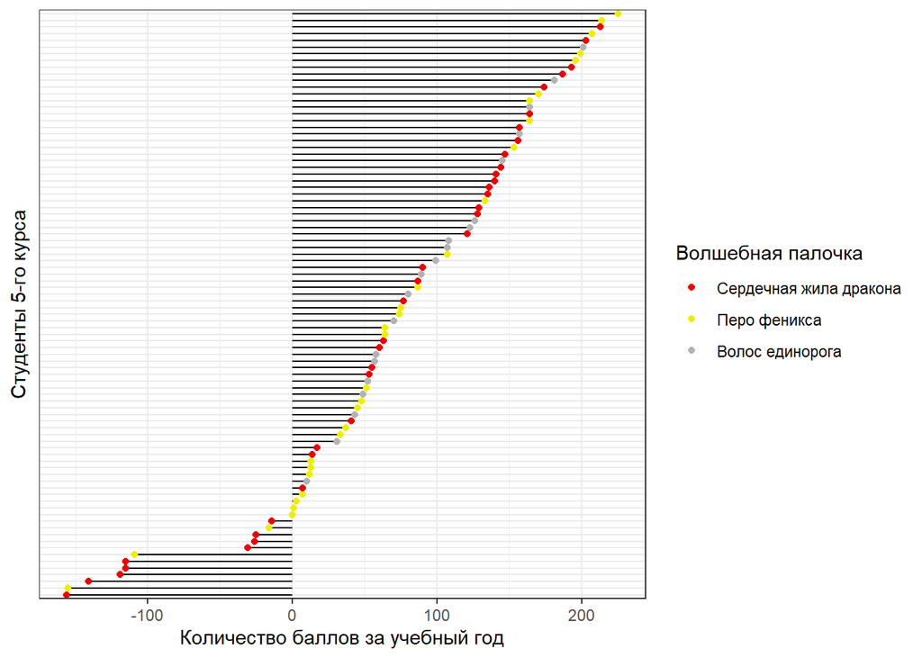

```r
data %>%
  filter(course == 5) %>%
  mutate(id = as.factor(id)) %>%
  ggplot()+
  geom_segment(aes(x = 0, xend = result, y = fct_reorder(id, result),
                   yend = fct_reorder(id, result)))+
  geom_point(aes(result, fct_reorder(id, result), colour = fct_recode(wandCore,
                                                                      `Сердечная жила дракона` = "dragon heartstring",
                                                                      `Перо феникса` = "phoenix feather",
                                                                      `Волос единорога` = "unicorn hair")))+
  theme_bw()+
  labs(x = "Количество баллов за учебный год",
       y = "Студенты 5-го курса",
       colour = "Волшебная палочка")+
  scale_colour_manual(values = c("Сердечная жила дракона" = "red2",
                               "Перо феникса" = "yellow2",
                               "Волос единорога" = "gray70"))+
  theme(axis.text.y = element_blank(),
        axis.ticks.y = element_blank())
```

### Задание 2:

- Постройте гистограмму распредления баллов за экзамен по астрономии.
- Выделите цветом факультет Слизерин.
- Примените 18-й кегль к тексту на осях x, y и легенды.
- Название оси y и легенды запишите 20-м кеглем, оси x – 22-м.
- Измените название оси y на “Number of students”.

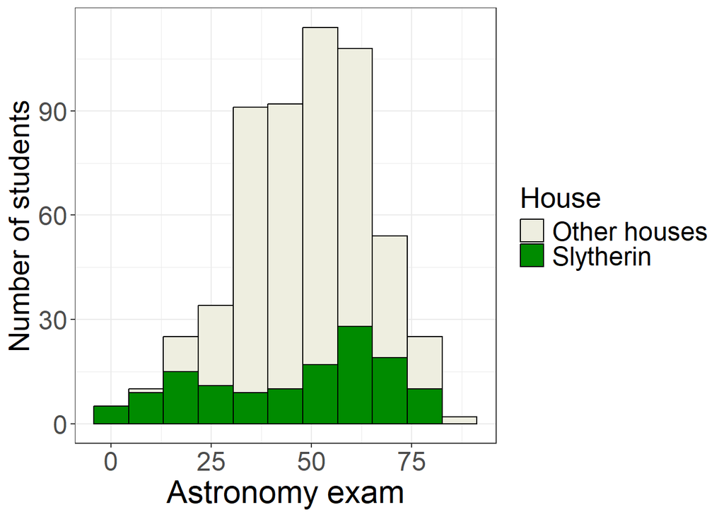

```r
ggplot(data)+
  geom_histogram(aes(`Astronomy exam`, fill = house == "Slytherin"),
                 bins = ceiling(log2(nrow(data))+1), colour = "black")+
  theme_bw()+
  labs(y = "Number of students",
       fill = "House")+
  scale_fill_manual(values = c("TRUE" = "green4", "FALSE" = "ivory2"),
                    labels = c("TRUE" = "Slytherin", "FALSE" = "Other houses")) +
  theme(axis.text  = element_text(size = 18),
        legend.text = element_text(size = 18),
        axis.title.x = element_text(size = 22),
        axis.title.y = element_text(size = 20),
        legend.title = element_text(size = 20))
```

### Задание 3:

- Модифицируйте theme_custom таким образом, чтобы она и выполняла свои прежние функции, и делала фон белым без помощи theme_bw().
- Примените новую кастомную тему к графику, полученному в последнем пункте блока по боксплотам.

[output not shown]

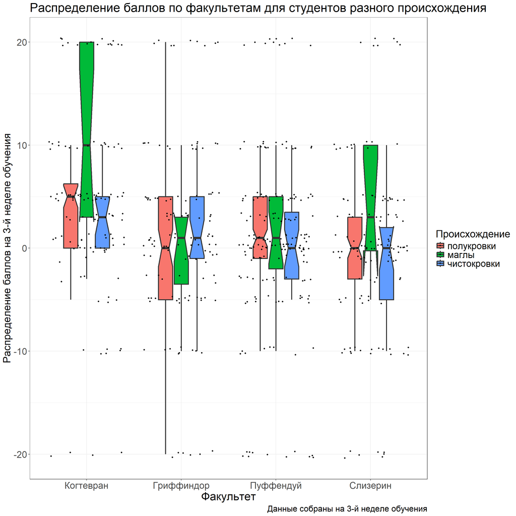

```r
theme_custom <- theme_bw()+ theme(
        axis.text  = element_text(size = 18),
        legend.text = element_text(size = 18),
        axis.title.x = element_text(size = 22),
        axis.title.y = element_text(size = 20),
        legend.title = element_text(size = 20),
        title = element_text(size = 20))

ggplot(data, aes(x = fct_reorder(fct_recode(house, Гриффиндор = "Gryffindor", Пуффендуй = "Hufflepuff",
                                            Когтевран = "Ravenclaw", Слизерин = "Slytherin"), week_3, .desc = TRUE),
                 y = week_3, fill = fct_recode(bloodStatus, маглы = "muggle-born", чистокровки = "pure-blood",
                                               полукровки = "half-blood"))) +
  geom_boxplot(notch = TRUE, outliers = FALSE, linewidth = 1, width = 0.5) +
  geom_jitter(size = 1) +
  labs(x = "Факультет", y = "Распределение баллов на 3-й неделе обучения", fill = "Происхождение",
       title = "Распределение баллов по факультетам для студентов разного происхождения",
       caption = "Данные собраны на 3-й неделе обучения")+
  theme_custom
```

## Фасетирование

## Задание 1:

- Напишите, какой, по вашему мнению, способ фасетирования (по строкам или по столбцам) лучше использовать для визуализации гистограммы. Почему?
- А какой для визуализации violin-plot? Почему?
- Можно ли вывести общее правило?

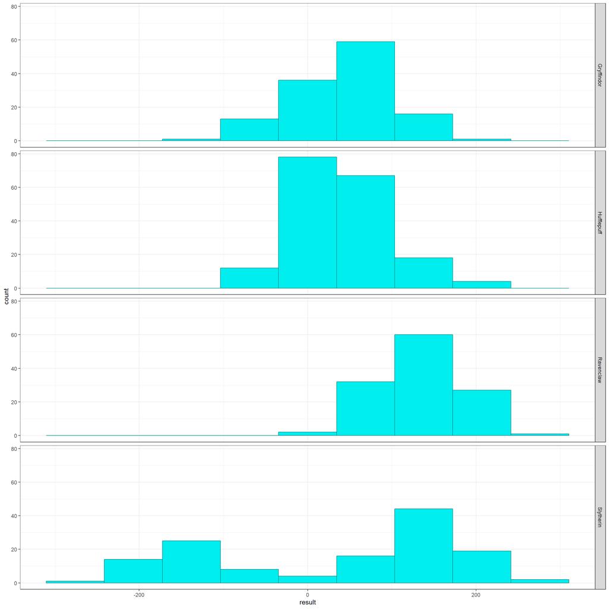

```r
ggplot(data)+
  geom_histogram(aes(result),
                 bins = ceiling(log2(nrow(data)/4 )+1), colour = "cyan4", fill = "cyan2"  )+
  theme_bw()+
  facet_grid(house ~ .)
```

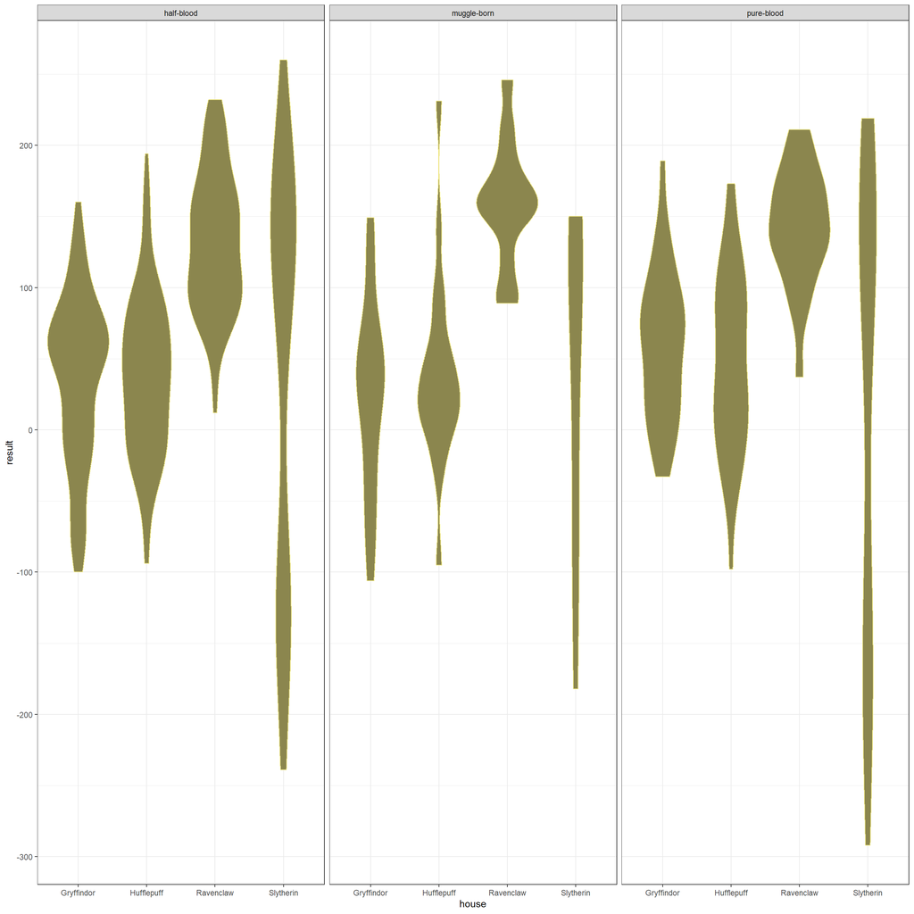

```r
ggplot(data)+
  geom_violin(aes(house, result), colour = "khaki2", fill = "khaki4")+
  theme_bw()+
  facet_grid(. ~ bloodStatus)
```

1. **Гистограммы:** cпособ фасетирования - по строкам. Это позволяет лучше увидеть разброс значений по оси X и удобно сравнить распределения между категориями.
2. **Violin-plot:** cпособ фасетирования - по столбцам. Это облегчает сравнение распределений по оси Y, делая визуализацию более понятной.
3. **Общее правило:** cледует выбирать способ фасетирования в зависимости от того, какая ось (X или Y) важнее для анализа разброса данных.

## Задание 2:

- Постройте гистограмму для результата любого выбранного вами экзамена, кроме зельеварения.
- Настройте оптимальное на ваш взгляд число столбцов гистограммы.
- Выполните фасетирование по курсу.
- Постарайтесь, чтобы график был по возможности компактным.

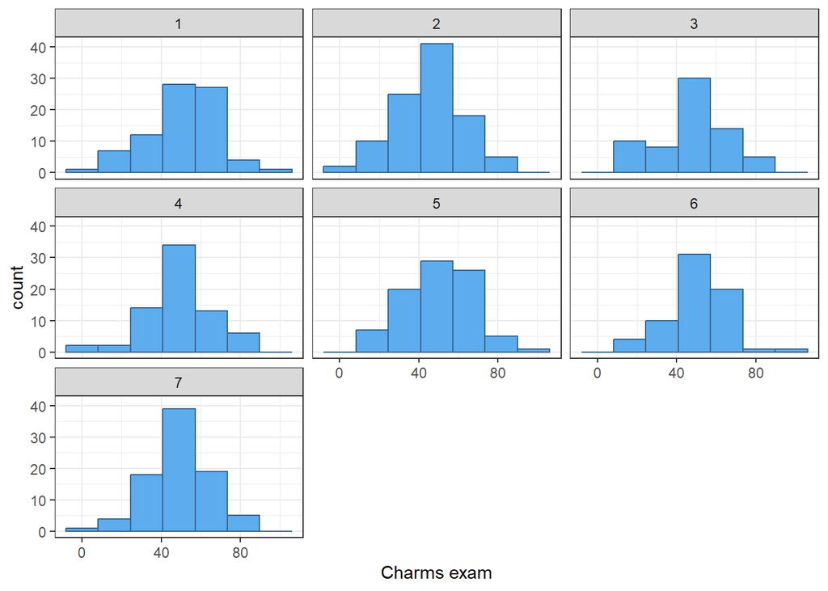

```r
ggplot(data)+
  geom_histogram(aes(`Charms exam`),
                 bins = ceiling(log2(nrow(data)/7 + 1)), colour = "steelblue4", fill = "steelblue2"  )+
  theme_bw()+
  facet_wrap(vars(course))
```

## Задание 3:

- Отобразите на одном графике распределение плотности вероятности для оценки студентов на экзамене по защите от темных искусств и на экзамене по травологии.
- Раскрасьте их в любые выбранные вами цвета, постарайтесь, чтобы оба распределения отображались целиком.
- Примените тему из 3-го пункта блока “Разное”.
- Сделайте фасетирование по полу.

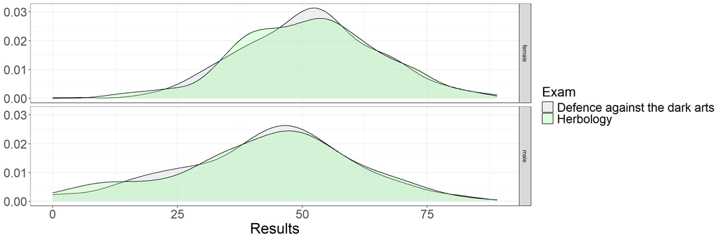

```r
ggplot(data) +
  geom_density(aes(x = `Defence against the dark arts exam`, fill = "A"), alpha = 0.3) +
  geom_density(aes(x = `Herbology exam`, fill = "B"), alpha = 0.3) +
  scale_fill_manual(values = c("A" = "azure3", "B" = "palegreen"),
                    labels = c("A" = "Defence against the dark arts", "B" = "Herbology")) +
  labs(fill = "Exam", x = "Results", y = NULL) +
  theme_custom +
  facet_grid(sex ~ .)
```